# Data exploration

## 3 Hands On: Data Exploration.

### 1 Summarization Load the data set carIns final. It already has the imputation of missing values. 1. Using the package dplyr, answer the following questions:

```r
install.packages("dplyr")
library(dplyr)
```

```r
load("../data/03_data_exploration/carIns_final.Rdata")
head(carIns_final)
```

1. Obtain the number of cars by bodyStyle.

```r
# Calculate the counts of cars by bodyStyle
car_counts <- table(carIns_final$bodyStyle)

# Print the counts
print(car_counts)
```

2. Obtain the number of cars by bodyStyle and fuelType.

```r
# Calculate the counts of cars by bodyStyle and fuelType
car_counts <- table(carIns_final$bodyStyle, carIns_final$fuelType)

# Print the counts
print(car_counts)
```

3. Obtain the mean and the standard deviation of the attribute cityMpg by bodyStyle in ascending order.

```r
# Calculate the mean and standard deviation of cityMpg by bodyStyle
car_summary <- carIns_final %>%
  group_by(bodyStyle) %>%
  summarise(mean_cityMpg = mean(cityMpg),
            sd_cityMpg = sd(cityMpg)) %>%
  arrange(mean_cityMpg)

# Print the summary
print(car_summary)
```

4. Also by bodyStyle, and for the attributes cityMpg and highwayMpg, obtain the mean, the standard deviation, the median and the inter-quartile range

```r
# Calculate the summary statistics by bodyStyle for cityMpg and highwayMpg
car_summary <- carIns_final %>%
  group_by(bodyStyle) %>%
  summarise(mean_cityMpg = mean(cityMpg),
            sd_cityMpg = sd(cityMpg),
            median_cityMpg = median(cityMpg),
            IQR_cityMpg = IQR(cityMpg),
            mean_highwayMpg = mean(highwayMpg),
            sd_highwayMpg = sd(highwayMpg),
            median_highwayMpg = median(highwayMpg),
            IQR_highwayMpg = IQR(highwayMpg))

# Print the summary
print(car_summary)
```

### 2 Visualization.- Using the package ggplot2, create graphs that you find adequate to answer the following questions:

```r
install.packages("ggplot2")
library(ggplot2)
```

5. Show the relationship between the attributes cityMpg and highwayMpg

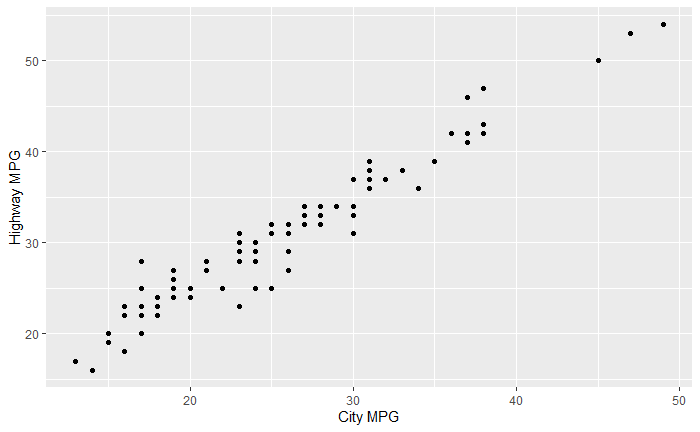

```r
# Create scatter plot
ggplot(carIns_final, aes(x = cityMpg, y = highwayMpg)) +
  geom_point() +
  xlab("City MPG") +
  ylab("Highway MPG")
```

6. Show the distribution of cars by bodyStyle.

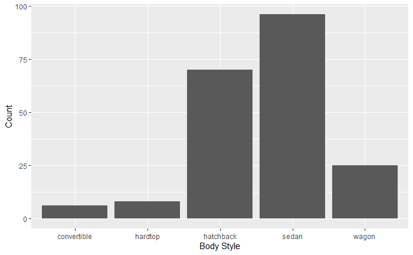

```r
# Create bar plot
ggplot(carIns_final, aes(x = bodyStyle)) +
  geom_bar() +
  xlab("Body Style") +
  ylab("Count")
```

7. Show the distribution of cars by price. Suggestion: create bins of width equal to 5000.

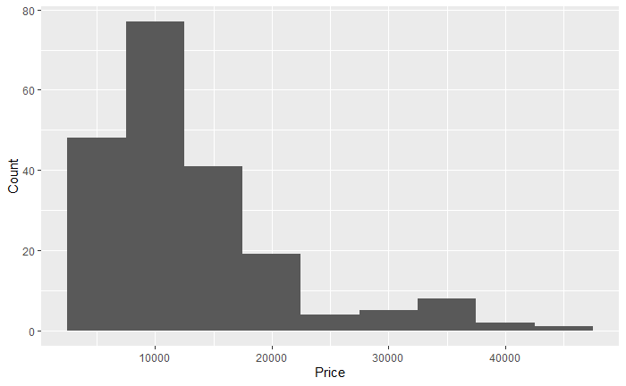

```r
# Create histogram with bins of width equal to 5000
ggplot(carIns_final, aes(x = price)) +
  geom_histogram(binwidth = 5000) +
  xlab("Price") +
  ylab("Count")
```

8. Add the information of the density estimation to the previous graph.

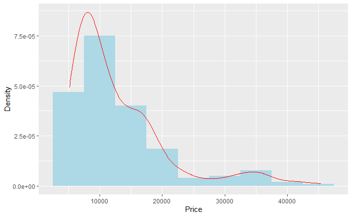

```r
# Create histogram with density overlay
ggplot(carIns_final, aes(x = price)) +
  geom_histogram(binwidth = 5000, aes(y = ..density..), fill = "lightblue") +
  geom_density(alpha = 0.5, color = "red") +
  xlab("Price") +
  ylab("Density")
```

1. Check (visually) if it is plausible to consider that price follows a normal distribution.

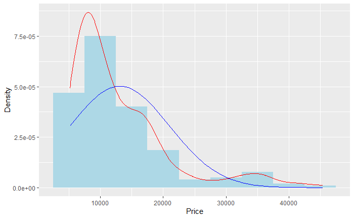

```r
# Create a histogram with density overlay
ggplot(carIns_final, aes(x = price)) +
  geom_histogram(binwidth = 5000, aes(y = ..density..), fill = "lightblue") +
  geom_density(color = "red") +
  xlab("Price") +
  ylab("Density") +
  stat_function(fun = dnorm, args = list(mean = mean(carIns_final$price), sd = sd(carIns_final$price)), color = "blue")
```

10. Show the distribution of price by make attribute. Suggestion: use boxplots and the function coord_flip().

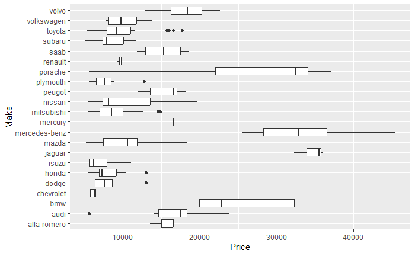

```r
# Create a boxplot with flipped coordinates
ggplot(carIns_final, aes(x = make, y = price)) +
  geom_boxplot() +
  xlab("Make") +
  ylab("Price") +
  coord_flip()
```

11. Show the distribution of price by nDoors attribute. Suggestion: use histograms.

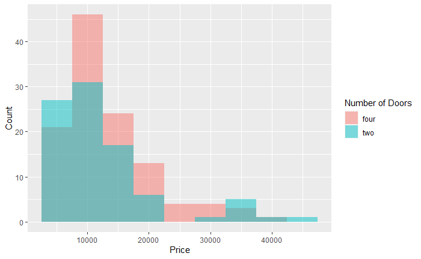

```r
# Create a histogram with different colors for nDoors
ggplot(carIns_final, aes(x = price, fill = nDoors)) +
  geom_histogram(binwidth = 5000, position = "identity", alpha = 0.5) +
  xlab("Price") +
  ylab("Count") +
  scale_fill_discrete(name = "Number of Doors")
```

12. Show the distribution of price by bodyStyle and nDoors attributes. Suggestion: use histograms.

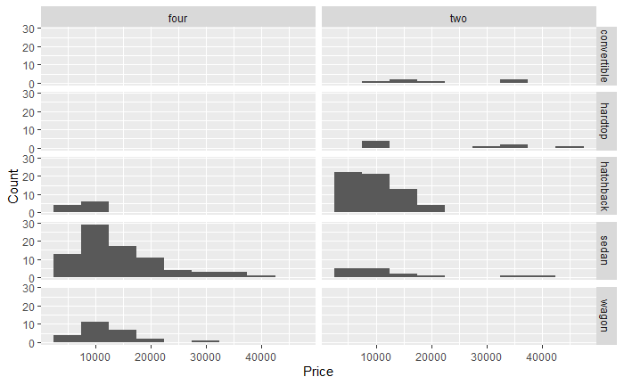

```r
# Create histograms for bodyStyle and facets for nDoors
ggplot(carIns_final, aes(x = price)) +
  geom_histogram(binwidth = 5000) +
  facet_grid(bodyStyle ~ nDoors) +
  xlab("Price") +
  ylab("Count")
```

13. Add the parameter scales=“free_y” to the facet function in the previous graph

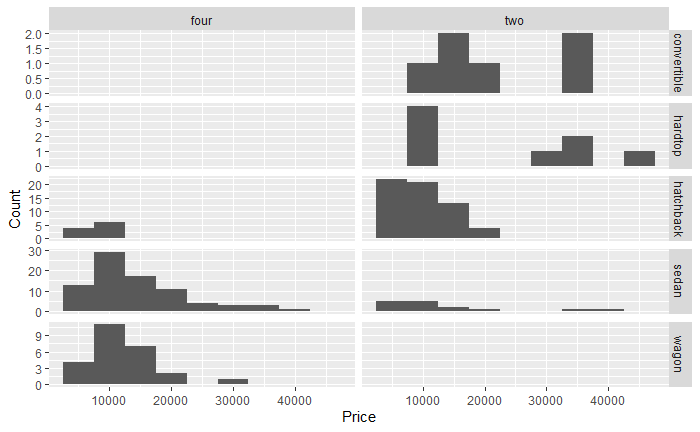

```r
# Create a histogram with free_y
ggplot(carIns_final, aes(x = price)) +
  geom_histogram(binwidth = 5000) +
  facet_grid(bodyStyle ~ nDoors, scales = "free_y") +
  xlab("Price") +
  ylab("Count")
```